# Experiment 1 - Analysis Pipeline

# 0. Setup & Libraries

```r
library(tidyverse)
library(rstan)
library(brms)
library(emmeans)
library(bayesplot)
library(kableExtra)
library(ggpubr)

# clear workspace
rm(list = ls())

# create relative folders if not exist
dir.create("model_outputs/statistical_modelling_brms/experiment_1", showWarnings = FALSE, recursive = TRUE)
dir.create("results/tables", showWarnings = FALSE, recursive = TRUE)
dir.create("results/figures", showWarnings = FALSE, recursive = TRUE)

# shared publication theme; keep data colours in each plot's manual scale
theme_paper = function(base_size = 16, aspect_ratio = 1) {
  theme_bw(base_size = base_size) +
    theme(plot.title = element_text(hjust = 0.5, size = 12),
          panel.grid.minor = element_blank(),
          panel.grid.major.x = element_blank(),
          panel.grid.major.y = element_line(colour = "grey90", linewidth = 0.3),
          panel.border = element_rect(fill = NA, colour = "grey70", linewidth = 0.4),
          text = element_text(colour = "#4A4A4A", family = "Helvetica"),
          axis.text = element_text(size = 9, colour = "#4A4A4A"),
          axis.title = element_text(size = 11),
          strip.text = element_text(size = 11, colour = "#4A4A4A", face = "bold"),
          strip.background = element_rect(fill = "grey96", colour = NA),
          aspect.ratio = aspect_ratio,
          plot.margin = margin(12, 8, 12, 4, "pt"),
          legend.position = "bottom",
          legend.title.align = 0.5,
          legend.text = element_text(size = 9),
          legend.title = element_text(size = 10))
}
```

# 1. Data Loading & Exclusions

```r
D = readRDS("analysis_data/experiment_1_analysis.rds")
cat(sprintf("Raw N = %d participants\n", length(unique(D$SubjID))))
```

```
## Raw N = 56 participants
```

```r
# remove people with low hit rate
d1 = D %>% filter(hittoolow == 0)
cat(sprintf("hit-rate exclusion: N = %d\n", length(unique(D$SubjID))-length(unique(d1$SubjID))))
```

```
## hit-rate exclusion: N = 1
```

```r
# remove people with low music imagery
d2 = d1 %>% filter(avg_musicvividlessthan2 == 0)
cat(sprintf("imagery-vividness exclusion: N = %d\n", length(unique(d1$SubjID))-length(unique(d2$SubjID))))
```

```
## imagery-vividness exclusion: N = 3
```

```r
# remove people with super fast RTs
RT = d2 %>%
  group_by(SubjID) %>%
  mutate(bad_RT = ifelse(response_time < 150, 1, 0)) %>%
  summarise(bad_sub_RT = ifelse(mean(bad_RT) > 0.25, 1, 0))

d3 = merge(d2, RT, by = "SubjID") %>% filter(bad_sub_RT == 0)

cat(sprintf("People with >25%% RTs faster than 150 ms: N = %d\n", length(unique(d2$SubjID))-length(unique(d3$SubjID))))
```

```
## People with >25% RTs faster than 150 ms: N = 1
```

```r
# remove people with over 95% same responses (smashing the same buttons??)
response_screen = d3 %>%
  group_by(SubjID) %>%
  summarise(uniform_response = ifelse(max(mean(binary_resp), 1 - mean(binary_resp))>=0.95, 1, 0),
            .groups = "drop")

d = merge(d3, response_screen, by = "SubjID") %>% filter(uniform_response == 0)

cat(sprintf("Same button smasher: N = %d\n", length(unique(d3$SubjID))-length(unique(d$SubjID))))
```

```
## Same button smasher: N = 1
```

```r
cat(sprintf("Final sample: N = %d\n", length(unique(d$SubjID))))
```

```
## Final sample: N = 50
```

```r
# remove intermiediate dfs from memory
rm(D, d1, d2, d3, RT, response_screen)
```

# 2. Demographics & Sample Description

```r
desc = d %>%
  group_by(SubjID) %>%
  summarise(
    male = ifelse(unique(subject_gender) == "Male", 1, 0),
    age = unique(subject_age),
    lshs = unique(lshs_score)
  ) %>%
  ungroup() %>%
  as.data.frame()

cat(sprintf("Age: M = %.1f, SD = %.1f\n", mean(desc$age), sd(desc$age)))
```

```
## Age: M = 34.1, SD = 15.6
```

```r
cat(sprintf("Gender: %d male, %d female\n", sum(desc$male), sum(1 - desc$male)))
```

```
## Gender: 12 male, 38 female
```

```r
cat(sprintf("Hallucination Proneness (LSHSr): M = %.1f, SD = %.1f, range = %d-%d (within 16-80 range)\n",
            mean(desc$lshs), sd(desc$lshs), min(desc$lshs), max(desc$lshs)))
```

```
## Hallucination Proneness (LSHSr): M = 38.7, SD = 13.3, range = 16-69 (within 16-80 range)
```

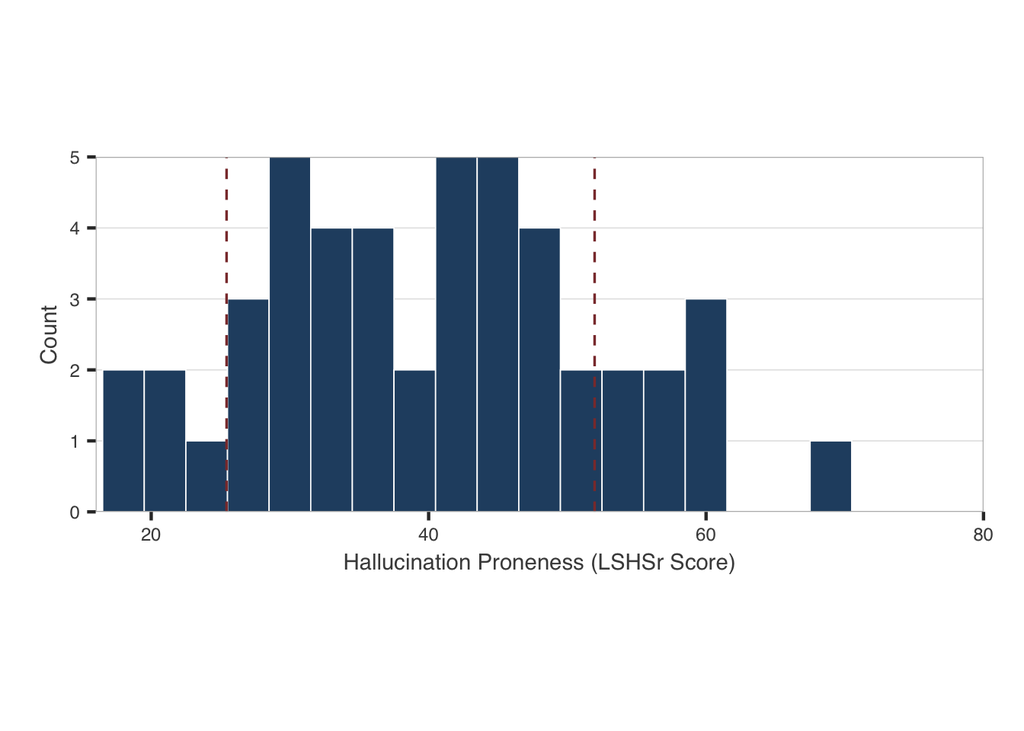

```r
lshs_m = mean(desc$lshs)
lshs_sd = sd(desc$lshs)

p_lshs = ggplot(desc, aes(x = lshs)) +
  geom_histogram(binwidth = 3, fill = "#264E70", color = "white", linewidth = 0.3) +
  geom_vline(xintercept = lshs_m - lshs_sd, linetype = "dashed", color = "#8B3A3A", linewidth = 0.6) +
  geom_vline(xintercept = lshs_m + lshs_sd, linetype = "dashed", color = "#8B3A3A", linewidth = 0.6) +
  scale_x_continuous(expand = c(0, 0), limits = c(16, 80)) +
  scale_y_continuous(expand = c(0, 0)) +
  labs(x = "Hallucination Proneness (LSHSr Score)", y = "Count") +
  theme_paper(base_size = 17, aspect_ratio = 0.4) +
  theme(plot.margin = margin(2, 20, 2, 20), legend.position = "none")
print(p_lshs)
```

# 3. Custom functions

```r
# creates a formatted fixed-effect table with BF10 and evidence stars for H0 and H1
# *** = BF10 < 1/100 or > 100; ** = < 1/10 or > 10; * = < 1/3 or > 3
format_bf = function(bf) {
  ifelse(is.na(bf), NA_character_,
         ifelse(is.infinite(bf), "Inf",
                ifelse(bf >= 100 | (bf > 0 & bf < 0.01),
                       formatC(bf, format = "e", digits = 2),
                       sprintf("%.2f", bf))))
}

report_bmm_fixef = function(model, caption = NULL) {
  estimates = fixef(model) %>% as.data.frame() %>% rownames_to_column("term") %>% dplyr::select(term, Estimate, Est.Error, Q2.5, Q97.5)

  terms = estimates$term
  bf_results = data.frame(term = character(), BF10 = character(), H0 = character(), H1 = character())

  for (term in terms) {
    hyp = hypothesis(model, paste(term, "= 0"))
    # the point-null hypothesis gives BF01, so invert it for BF10
    BF10_raw = abs(1 / hyp$hypothesis$Evid.Ratio)
    H0_ind = ifelse(BF10_raw < (1/100), "***", ifelse(BF10_raw < (1/10), "**", ifelse(BF10_raw < (1/3), "* ", "")))
    H1_ind = ifelse(BF10_raw > 100, "***", ifelse(BF10_raw > 10, "**", ifelse(BF10_raw > 3, "* ", "")))

    bf_results = rbind(bf_results, data.frame(term = term, BF10 = format_bf(BF10_raw), H0 = H0_ind, H1 = H1_ind))
  }

  final_table = estimates %>% left_join(bf_results, by = "term") %>% rename("2.5%" = Q2.5, "97.5%" = Q97.5)
  return(kable(final_table, digits = 2, caption = caption, escape = TRUE) %>% kable_classic("hover", full_width = FALSE, html_font = "Arial", position = "left"))
}

# extracts the same fixed effects and BF10 values as a data frame for saving as csv
# BF10_raw stays numeric for later analysis, while BF10 is formatted for display
extract_bmm_fixef = function(model) {
  estimates = fixef(model) %>% as.data.frame() %>% rownames_to_column("term") %>% dplyr::select(term, Estimate, Est.Error, Q2.5, Q97.5)

  terms = estimates$term
  bf_results = data.frame(term = character(), BF10_raw = numeric(), BF10 = character(), stringsAsFactors = FALSE)

  for (term in terms) {
    hyp = hypothesis(model, paste(term, "= 0"))
    # the point-null hypothesis gives BF01, so invert it for BF10
    BF10_raw = abs(1 / hyp$hypothesis$Evid.Ratio)
    bf_results = rbind(bf_results, data.frame(term = term, BF10_raw = BF10_raw, BF10 = format_bf(BF10_raw), stringsAsFactors = FALSE))
  }

  estimates %>% left_join(bf_results, by = "term") %>% rename("2.5%" = Q2.5, "97.5%" = Q97.5)
}


# checks the worst Rhat, bulk ESS and tail ESS across all parameters, plus total divergences
# if the model fails, the error identifies every failed threshold and its actual value
check_brms_diagnostics = function(model, label) {
  draw_summary = posterior::summarise_draws(posterior::as_draws_array(model))
  max_rhat = max(draw_summary$rhat, na.rm = TRUE)
  min_bulk_ess = min(draw_summary$ess_bulk, na.rm = TRUE)
  min_tail_ess = min(draw_summary$ess_tail, na.rm = TRUE)
  max_rhat_parameter = draw_summary$variable[which.max(draw_summary$rhat)]
  min_bulk_ess_parameter = draw_summary$variable[which.min(draw_summary$ess_bulk)]
  min_tail_ess_parameter = draw_summary$variable[which.min(draw_summary$ess_tail)]
  sampler_diagnostics = brms::nuts_params(model)
  divergences = sum(sampler_diagnostics$Parameter == "divergent__" & sampler_diagnostics$Value == 1)

  problems = character()
  if (max_rhat > 1.01) problems = c(problems, sprintf("max Rhat = %.3f for %s (> 1.01)", max_rhat, max_rhat_parameter))
  if (min_bulk_ess < 400) problems = c(problems, sprintf("min bulk ESS = %.0f for %s (< 400)", min_bulk_ess, min_bulk_ess_parameter))
  if (min_tail_ess < 400) problems = c(problems, sprintf("min tail ESS = %.0f for %s (< 400)", min_tail_ess, min_tail_ess_parameter))
  if (divergences > 0) problems = c(problems, sprintf("divergences = %d (> 0)", divergences))

  if (length(problems) > 0) stop(sprintf("%s did not pass diagnostics: %s", label, paste(problems, collapse = "; ")), call. = FALSE)
  cat(sprintf("%s passed diagnostics: max Rhat = %.3f; min bulk ESS = %.0f; min tail ESS = %.0f; divergences = %d\n", label, max_rhat, min_bulk_ess, min_tail_ess, divergences))
}

# reverses the direction of an estimate and swaps its lower and upper interval bounds
# this is for flipping the signal for the criterion measure which in brms framework is more like
# 'willingness' so needs to be flipped to create 'criterion'
signflip = function(df, cols = c("emmean", "lower.HPD", "upper.HPD")) {
  df[cols] = df[cols] * -1
  # multiplying by -1 reverses the interval, so put the bounds back in order
  temp = df[[cols[2]]]
  df[[cols[2]]] = df[[cols[3]]]
  df[[cols[3]]] = temp
  df
}

prior_position = position_dodge(width = 0.18)
```

# 4. Variable Coding

- **signal**: deviation-coded (+/-0.5), positive = signal present
- **fam**: deviation-coded (+/-0.5), positive = familiar/strong prior
- **musicvivid**: z-scored / 2 (mean=0, SD=0.5)
- **lshs**: z-scored / 2 (mean=0, SD=0.5) Dividing by 2 puts continuous predictors on the same scale as deviation-coded factors.

```r
d.SDT = d %>%
  dplyr::select(SubjID, familiar, interference, avg_block_music_vivid,
                volume, binary_resp, lshs_score) %>%
  mutate(
    signal = scale(ifelse(volume > 0, 1, 0), scale = FALSE),
    fam = scale(familiar, scale = FALSE),
    musicvivid = scale(avg_block_music_vivid)/2,
    lshs = scale(lshs_score)/2
  ) %>%
  rename(resp = binary_resp)

cat(sprintf("SDT dataset: %d trials from %d participants\n",
            nrow(d.SDT), length(unique(d.SDT$SubjID))))
```

```
## SDT dataset: 10000 trials from 50 participants
```

```r
# HGF trait parameter one row per participant x condition
# HGF trait parameter analysed here: prior_posterior_weight
hgf_para = read.csv("model_outputs/computational_modelling_hgf/experiment_1/parameter_estimates_df.csv") %>%
  mutate(familiar = ifelse(condition < 3, 0, 1))

d.musicvivid = d %>%
  group_by(SubjID, familiar) %>%
  summarise(music_vivid = mean(avg_block_music_vivid),
            lshs = unique(lshs_score),
            .groups = "drop")

hgf_para = merge(hgf_para, d.musicvivid, by = c("SubjID", "familiar"))

d.hgf.session = hgf_para %>%
  mutate(fam = scale(familiar, scale = FALSE),
         musicvivid = scale(music_vivid)/2,
         lshs = scale(lshs)/2,
         SubjID = as.factor(SubjID),
         zPPW = scale(prior_posterior_weight))

rm(hgf_para, d.musicvivid)

cat(sprintf("HGF trait dataset: %d rows (participant x condition)\n", nrow(d.hgf.session)))
```

```
## HGF trait dataset: 100 rows (participant x condition)
```

```r
# HGF state parameters, i.e. trial-by-trial trajectories recovered by replaying
# observed responses. The state on each task row follows the preceding response.
hgf_traj = read.csv("model_outputs/computational_modelling_hgf/experiment_1/estimated_state_trajectories.csv") %>%
  group_by(SubjID, condition) %>%
  arrange(timestep, .by_group = TRUE) %>%
  mutate(trialID = cumsum(training == 0)) %>%
  filter(training == 0) %>%
  ungroup()

d.hgf.trial = d %>%
  mutate(condition = case_when(
    familiar == 0 & interference == "noise" ~ 1,
    familiar == 0 & interference == "music" ~ 2,
    familiar == 1 & interference == "noise" ~ 3,
    familiar == 1 & interference == "music" ~ 4
  )) %>%
  merge(hgf_traj, by = c("SubjID", "condition", "trialID")) %>%
  arrange(SubjID, condition, trialID) %>%
  mutate(
    SubjID = as.factor(SubjID),
    fam = scale(familiar, scale = FALSE),
    musicvivid = scale(avg_block_music_vivid)/2,
    lshs = scale(lshs_score)/2,
    # xbin prediction is the signal expectation before the current HGF update; its logit is xprob posterior from t-1
    zmu_xprob = scale(qlogis(xbin__prediction_mean)),
    ztrialID = scale(trialID)
  )

rm(hgf_traj)

cat(sprintf("HGF state dataset: %d trial-level rows\n", nrow(d.hgf.trial)))
```

```
## HGF state dataset: 10000 trial-level rows
```

# 5. Manipulation Checks

## 5.1 Auditory Prior Check: Signal Vividness (Strong > Weak)

```r
manipcheck = d %>%
  group_by(SubjID, familiar) %>%
  summarise(meanvivid = unique(response_Speech_vividness), .groups = "drop") %>%
  pivot_wider(id_cols = SubjID,
              names_from = familiar,
              values_from = meanvivid)

tt = t.test(manipcheck$`1`, manipcheck$`0`, paired = TRUE)

cat(sprintf("Strong Prior: M = %.1f\n", mean(manipcheck$`1`)))
```

```
## Strong Prior: M = 4.6
```

```r
cat(sprintf("Weak Prior:   M = %.1f\n", mean(manipcheck$`0`)))
```

```
## Weak Prior:   M = 4.3
```

```r
cat(sprintf("Paired t(%d) = %.2f, p = %.3f\n", tt$parameter, tt$statistic, tt$p.value))
```

```
## Paired t(49) = 2.91, p = 0.005
```

## 5.2 Auditory Perturbation Check: Music Identification (Shape of You)

```r
manipcheck2 = d %>%
  filter(interference == "music") %>%
  group_by(SubjID) %>%
  summarise(knowit = ifelse(any(music_identified == 1), 1, 0),
            musicvivid = mean(avg_block_music_vivid))

cat(sprintf("Song/artist identified: %.1f%%\n", mean(manipcheck2$knowit) * 100))
```

```
## Song/artist identified: 74.0%
```

```r
cat(sprintf("Music imagery vividness: M = %.1f, SD = %.1f\n",
            mean(manipcheck2$musicvivid), sd(manipcheck2$musicvivid)))
```

```
## Music imagery vividness: M = 3.9, SD = 0.9
```

```r
tt2 = t.test(manipcheck2[manipcheck2$knowit == 1, ]$musicvivid,
              manipcheck2[manipcheck2$knowit == 0, ]$musicvivid)

cat(sprintf("Vividness by identification: t(%.1f) = %.2f, p = %.3f\n",
            tt2$parameter, tt2$statistic, tt2$p.value))
```

```
## Vividness by identification: t(23.5) = 0.56, p = 0.578
```

Knowing the song did not affect imagery vividness.

# 6. Priors

**SDT priors** (probit link): Intercept ~ N(-0.67, 0.38), b ~ N(0, 0.5), sd ~ t(3, 0, 0.5)

**HGF priors** (gaussian, z-scored DVs): Intercept ~ N(0, 1), b ~ N(0, 1), sd ~ t(3, 0, 1). Sigma and alpha (skew_normal) use brms defaults.

```r
priors_SDT = c(
  set_prior("normal(-0.67, 0.38)", class = "Intercept"),
  set_prior("normal(0, 0.5)", class = "b"),
  set_prior("student_t(3, 0, 0.5)", class = "sd")
)

priors_hgf = c(
  set_prior("normal(0, 1)", class = "Intercept"),
  set_prior("normal(0, 1)", class = "b"),
  set_prior("student_t(3, 0, 1)", class = "sd")
)
```

# 7. Model 1: Signal Detection Theory (d’ and c)

The primary SDT model. Decomposes detection into sensitivity (d’) and criterion (c) via probit SDT parameterisation.

## 7.1 Model specification + load

```r
bmm.sdt = brm(
  formula = bf(resp ~ signal * fam * musicvivid * lshs + (1 + signal * fam || SubjID)),
  data = d.SDT,
  family = bernoulli("probit"),
  prior = priors_SDT,
  sample_prior = TRUE,
  seed = 666,
  chains = 4,
  cores = 4,
  backend = "cmdstanr"
)
saveRDS(bmm.sdt, "model_outputs/statistical_modelling_brms/experiment_1/sdt.rds")
```

```r
bmm.sdt = readRDS("model_outputs/statistical_modelling_brms/experiment_1/sdt.rds")
check_brms_diagnostics(bmm.sdt, "SDT")
```

```
## SDT passed diagnostics: max Rhat = 1.005; min bulk ESS = 899; min tail ESS = 1703; divergences = 0
```

```r
report_bmm_fixef(bmm.sdt, caption = "SDT Model: Fixed Effects (bernoulli/probit, all trials)")
```

SDT Model: Fixed Effects (bernoulli/probit, all trials)

term

Estimate

Est.Error

2.5%

97.5%

BF10

H0

H1

Intercept

-0.18

0.07

-0.32

-0.04

NA

NA

NA

signal

1.28

0.13

1.02

1.52

2.97e+33

***

fam

-0.01

0.12

-0.26

0.22

0.24

musicvivid

0.06

0.10

-0.14

0.24

0.24

lshs

0.00

0.14

-0.26

0.27

0.26

signal:fam

-0.01

0.16

-0.32

0.29

0.30

signal:musicvivid

0.17

0.14

-0.11

0.45

0.57

fam:musicvivid

0.06

0.19

-0.31

0.44

0.41

signal:lshs

-0.11

0.22

-0.54

0.31

0.46

fam:lshs

0.53

0.24

0.06

0.99

4.84

musicvivid:lshs

0.09

0.19

-0.30

0.47

0.43

signal:fam:musicvivid

-0.12

0.31

-0.74

0.48

0.65

signal:fam:lshs

0.48

0.27

-0.07

1.02

2.59

signal:musicvivid:lshs

0.19

0.25

-0.32

0.69

0.63

fam:musicvivid:lshs

0.63

0.34

-0.04

1.31

3.77

signal:fam:musicvivid:lshs

-0.25

0.43

-1.09

0.57

0.94

```r
write.csv(extract_bmm_fixef(bmm.sdt), "results/tables/exp1_fixef_sdt.csv", row.names = FALSE)
```

## 7.2 Posterior Predictive Check

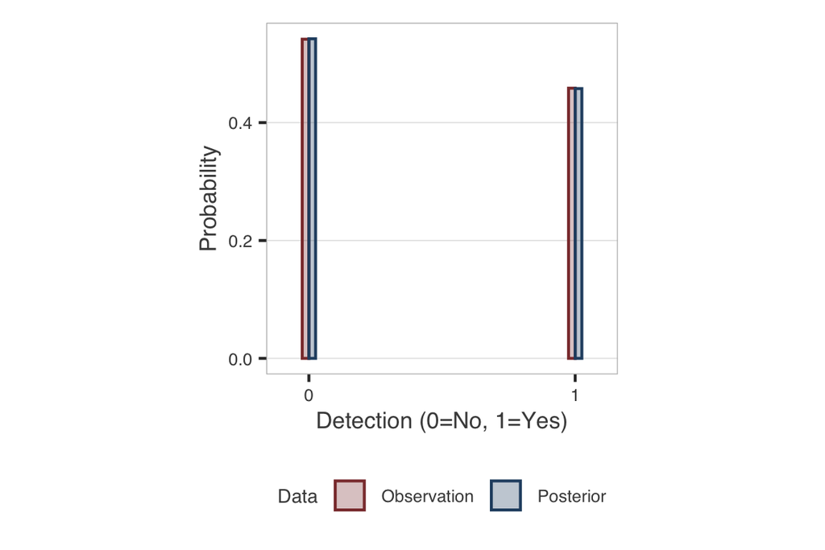

```r
set.seed(666)
posterior_predictions = posterior_predict(bmm.sdt, ndraws = 500)
posterior_check = data.frame(
  Measure = c(bmm.sdt$data$resp, as.vector(posterior_predictions)),
  Source = c(rep("Observation", nrow(bmm.sdt$data)),
             rep("Posterior", length(posterior_predictions)))
)
rm(posterior_predictions)

ggplot(posterior_check, aes(x = Measure, colour = Source, fill = Source)) +
  geom_bar(aes(y = after_stat(prop)), position = "dodge", stat = "count",
           alpha = 0.3, width = 0.05) +
  labs(x = "Detection (0=No, 1=Yes)", y = "Probability",
       colour = "Data", fill = "Data") +
  scale_colour_manual(values = c("Observation" = "#8B3A3A", "Posterior" = "#264E70")) +
  scale_fill_manual(values = c("Observation" = "#8B3A3A", "Posterior" = "#264E70")) +
  scale_x_continuous(limits = c(-0.1, 1.1), breaks = c(0, 1)) +
  theme_paper() +
  theme(axis.title = element_text(size = 12))
```

## 7.3 Sensitivity (d’): Auditory Prior x Hallucination Proneness

```r
ef_dprime = emtrends(bmm.sdt, ~ fam * lshs, var = "signal",
                     at = list(musicvivid = 0, lshs = c(-0.5, 0.5))) %>%
  as.data.frame() %>%
  mutate(Prior = factor(ifelse(fam < 0, "Weak", "Strong"), levels = c("Strong", "Weak")),
         Hallucination_Proneness = factor(ifelse(lshs < 0, "Low (-1SD)", "High (+1SD)"), levels = c("Low (-1SD)", "High (+1SD)"))) %>%
  arrange(desc(Hallucination_Proneness), Prior) %>%
  dplyr::select(Prior, Hallucination_Proneness, Sensitivity_dprime = signal.trend, Lower_HPD = lower.HPD, Upper_HPD = upper.HPD)

ef_dprime %>%
  kbl(digits = 2, caption = "Estimated Sensitivity (d') by Auditory Prior x Hallucination Proneness") %>%
  kable_styling(bootstrap_options = c("striped", "hover", "condensed"), full_width = FALSE) %>%
  row_spec(0, bold = TRUE)
```

Estimated Sensitivity (d’) by Auditory Prior x Hallucination Proneness

| Prior | Hallucination_Proneness | Sensitivity_dprime | Lower_HPD | Upper_HPD |
| --- | --- | --- | --- | --- |
| Strong | High (+1SD) | 1.33 | 0.93 | 1.71 |
| Weak | High (+1SD) | 1.11 | 0.72 | 1.49 |
| Strong | Low (-1SD) | 1.21 | 0.81 | 1.56 |
| Weak | Low (-1SD) | 1.47 | 1.07 | 1.84 |

```r
contrast_dprime_prior = contrast(emtrends(bmm.sdt, ~ fam | lshs, var = "signal", at = list(musicvivid = 0, lshs = c(-0.5, 0.5))), method = list("Strong - Weak" = c(-1, 1))) %>%
  as.data.frame() %>%
  mutate(Hallucination_Proneness = ifelse(lshs > 0, "High (+1SD)", "Low (-1SD)")) %>%
  dplyr::select(Hallucination_Proneness, contrast, estimate, lower.HPD, upper.HPD)

write.csv(ef_dprime, "results/tables/exp1_emmeans_dprime_prior_x_hallucination_proneness.csv", row.names = FALSE)
write.csv(contrast_dprime_prior, "results/tables/exp1_contrasts_dprime_prior_by_hallucination_proneness.csv", row.names = FALSE)
```

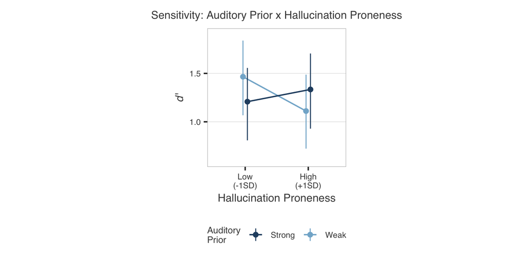

```r
weak_dprime = ef_dprime %>% filter(Prior == "Weak")
strong_dprime = ef_dprime %>% filter(Prior == "Strong")
weak_position = position_nudge(x = -0.035)
strong_position = position_nudge(x = 0.035)

p_dprime = ggplot(ef_dprime, aes(x = Hallucination_Proneness, y = Sensitivity_dprime, colour = Prior)) +
  geom_hline(yintercept = 0, linetype = "dotted", colour = "grey65", linewidth = 0.3) +
  geom_line(data = weak_dprime, aes(group = Prior), linewidth = 0.7, position = weak_position) +
  geom_linerange(data = weak_dprime, aes(ymin = Lower_HPD, ymax = Upper_HPD), linewidth = 0.5, position = weak_position) +
  geom_point(data = weak_dprime, size = 2, position = weak_position) +
  geom_line(data = strong_dprime, aes(group = Prior), linewidth = 0.7, position = strong_position) +
  geom_linerange(data = strong_dprime, aes(ymin = Lower_HPD, ymax = Upper_HPD), linewidth = 0.5, position = strong_position) +
  geom_point(data = strong_dprime, size = 2, position = strong_position) +
  scale_colour_manual(values = c("Weak" = "#82B3D1", "Strong" = "#264E70"), limits = c("Strong", "Weak")) +
  scale_x_discrete(labels = c("Low\n(-1SD)", "High\n(+1SD)")) +
  scale_y_continuous(limits = c(0.6, 1.9)) +
  theme_paper() +
  theme(axis.title = element_text(size = 12)) +
  labs(title = "Sensitivity: Auditory Prior x Hallucination Proneness",
       x = "Hallucination Proneness", y = expression(italic(d) * "'"), colour = "Auditory\nPrior")

print(p_dprime)
```

## 7.4 Criterion (c): Auditory Prior x Hallucination Proneness

```r
ef_criterion = emmeans(bmm.sdt, ~ fam * lshs,
                        at = list(lshs = c(-0.5, 0.5))) %>%
  as.data.frame() %>%
  mutate(
    fam = factor(ifelse(fam < 0, "Weak Prior", "Strong Prior"),
                 levels = c("Weak Prior", "Strong Prior")),
    lshs = factor(ifelse(lshs < 0, "Lower Proneness (-1SD)", "Higher Proneness (+1SD)"),
                  levels = c("Lower Proneness (-1SD)", "Higher Proneness (+1SD)"))
  ) %>%
  signflip()

ef_criterion %>%
  kbl(digits = 2, caption = "Estimated Criterion (c) by Auditory Prior x Hallucination Proneness (sign-flipped)") %>%
  kable_styling(bootstrap_options = c("striped", "hover", "condensed"), full_width = FALSE) %>%
  row_spec(0, bold = TRUE)
```

Estimated Criterion (c) by Auditory Prior x Hallucination Proneness (sign-flipped)

| fam | lshs | emmean | lower.HPD | upper.HPD |
| --- | --- | --- | --- | --- |
| Weak Prior | Lower Proneness (-1SD) | 0.19 | -0.06 | 0.48 |
| Strong Prior | Lower Proneness (-1SD) | 0.44 | 0.19 | 0.69 |
| Weak Prior | Higher Proneness (+1SD) | 0.41 | 0.17 | 0.68 |
| Strong Prior | Higher Proneness (+1SD) | 0.18 | -0.07 | 0.45 |

```r
write.csv(ef_criterion, "results/tables/exp1_emmeans_criterion_prior_x_hallucination_proneness.csv", row.names = FALSE)
```

### Pairwise: Auditory Prior slopes on criterion at each Hallucination Proneness level

```r
crit_fam_slopes = emtrends(bmm.sdt, ~ lshs, var = "fam",
                                     at = list(fam = c(-0.5, 0.5),
                                               lshs = c(-0.5, 0.5))) %>%
  as.data.frame() %>%
  mutate(Hallucination_Proneness = factor(ifelse(lshs < 0, "Lower Proneness (-1SD)", "Higher Proneness (+1SD)"),
                                          levels = c("Lower Proneness (-1SD)", "Higher Proneness (+1SD)"))
  ) %>%
  dplyr::select(Hallucination_Proneness, fam.trend, lower.HPD, upper.HPD) %>%
  signflip(cols = c("fam.trend", "lower.HPD", "upper.HPD"))

crit_fam_slopes %>%
  kbl(digits = 3, col.names = c("Hallucination Proneness", "Slope", "Lower HPD", "Upper HPD"),
      caption = "Criterion: Auditory Prior Slopes at Hallucination Proneness Levels (sign-flipped)") %>%
  kable_styling(bootstrap_options = c("striped", "hover", "condensed"), full_width = FALSE) %>%
  row_spec(0, bold = TRUE)
```

Criterion: Auditory Prior Slopes at Hallucination Proneness Levels (sign-flipped)

| Hallucination Proneness | Slope | Lower HPD | Upper HPD |
| --- | --- | --- | --- |
| Lower Proneness (-1SD) | 0.252 | -0.071 | 0.580 |
| Higher Proneness (+1SD) | -0.227 | -0.567 | 0.115 |

```r
write.csv(crit_fam_slopes, "results/tables/exp1_slopes_criterion_prior_by_hallucination_proneness.csv", row.names = FALSE)
```

### Figure: Criterion by Auditory Prior x Hallucination Proneness

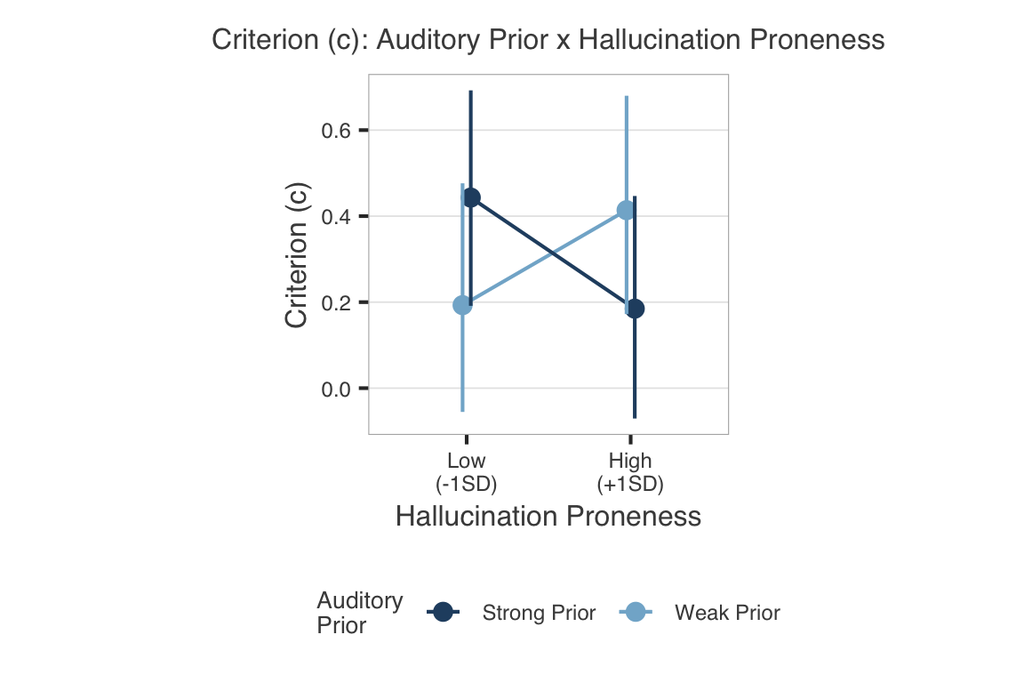

```r
fig_criterion = ggplot(ef_criterion, aes(x = lshs, y = emmean, color = fam)) +
  geom_point(size = 3, position = position_dodge(0.1)) +
  geom_line(aes(group = fam), position = position_dodge(0.1)) +
  geom_errorbar(aes(ymin = lower.HPD, ymax = upper.HPD),
                width = 0, position = position_dodge(0.1)) +
  scale_colour_manual(values = c("Weak Prior" = "#82B3D1", "Strong Prior" = "#264E70"),
                      limits = c("Strong Prior", "Weak Prior")) +
  scale_x_discrete(labels = c("Low\n(-1SD)", "High\n(+1SD)")) +
  labs(title = "Criterion (c): Auditory Prior x Hallucination Proneness",
       x = "Hallucination Proneness", y = "Criterion (c)", color = "Auditory\nPrior") +
  theme_paper() +
  theme(axis.title = element_text(size = 12))

print(fig_criterion)
```

## 7.5 Criterion (c): Auditory Prior x Auditory Perturbation x Hallucination Proneness

```r
ef_criterion = emmeans(bmm.sdt, ~ fam * musicvivid * lshs,
                        at = list(musicvivid = c(-0.5, 0.5),
                                  lshs = c(-0.5, 0.5))) %>%
  as.data.frame() %>%
  mutate(
    fam = factor(ifelse(fam < 0, "Weak Prior", "Strong Prior"),
                 levels = c("Weak Prior", "Strong Prior")),
    musicvivid = factor(ifelse(musicvivid < 0, "No\nImagery", "Music\nImagery"),
                        levels = c("No\nImagery", "Music\nImagery")),
    lshs = factor(ifelse(lshs < 0, "Lower Proneness (-1SD)", "Higher Proneness (+1SD)"),
                  levels = c("Lower Proneness (-1SD)", "Higher Proneness (+1SD)"))
  ) %>%
  arrange(desc(lshs), musicvivid, fam) %>%
  signflip()

ef_criterion %>%
  kbl(digits = 2, caption = "Estimated Criterion (c) by Auditory Prior x Auditory Perturbation x Hallucination Proneness (sign-flipped)") %>%
  kable_styling(bootstrap_options = c("striped", "hover", "condensed"), full_width = FALSE) %>%
  row_spec(0, bold = TRUE)
```

Estimated Criterion (c) by Auditory Prior x Auditory Perturbation x Hallucination Proneness (sign-flipped)

| fam | musicvivid | lshs | emmean | lower.HPD | upper.HPD |
| --- | --- | --- | --- | --- | --- |
| Weak Prior | No Imagery | Higher Proneness (+1SD) | 0.34 | 0.05 | 0.68 |
| Strong Prior | No Imagery | Higher Proneness (+1SD) | 0.32 | 0.02 | 0.62 |
| Weak Prior | Music Imagery | Higher Proneness (+1SD) | 0.48 | 0.19 | 0.76 |
| Strong Prior | Music Imagery | Higher Proneness (+1SD) | 0.05 | -0.31 | 0.37 |
| Weak Prior | No Imagery | Lower Proneness (-1SD) | 0.26 | -0.08 | 0.56 |
| Strong Prior | No Imagery | Lower Proneness (-1SD) | 0.38 | 0.08 | 0.75 |
| Weak Prior | Music Imagery | Lower Proneness (-1SD) | 0.13 | -0.22 | 0.46 |
| Strong Prior | Music Imagery | Lower Proneness (-1SD) | 0.50 | 0.22 | 0.82 |

```r
write.csv(ef_criterion, "results/tables/exp1_emmeans_criterion_3way.csv", row.names = FALSE)

ef_crit_3way = ef_criterion %>%
  mutate(Prior = factor(ifelse(fam == "Strong Prior", "Strong", "Weak"), levels = c("Strong", "Weak")),
         Perturbation = factor(ifelse(musicvivid == "Music\nImagery", "Imagery", "No Imagery"), levels = c("No Imagery", "Imagery")),
         Hallucination_Proneness = lshs) %>%
  dplyr::select(Prior, Perturbation, Hallucination_Proneness, Criterion_c = emmean, Lower_HPD = lower.HPD, Upper_HPD = upper.HPD)

contrast_criterion_prior = contrast(emmeans(bmm.sdt, ~ fam | musicvivid * lshs, at = list(musicvivid = c(-0.5, 0.5), lshs = c(-0.5, 0.5))), method = list("Strong - Weak" = c(-1, 1))) %>%
  as.data.frame() %>%
  signflip(cols = c("estimate", "lower.HPD", "upper.HPD")) %>%
  mutate(Perturbation = ifelse(musicvivid > 0, "Imagery", "No Imagery"), Hallucination_Proneness = ifelse(lshs > 0, "High (+1SD)", "Low (-1SD)")) %>%
  dplyr::select(Perturbation, Hallucination_Proneness, contrast, estimate, lower.HPD, upper.HPD)

write.csv(ef_crit_3way, "results/tables/exp1_emmeans_criterion_3way_labeled.csv", row.names = FALSE)
write.csv(contrast_criterion_prior, "results/tables/exp1_contrasts_criterion_prior_by_perturbation_x_hallucination_proneness.csv", row.names = FALSE)
```

### Pairwise: Auditory Perturbation slopes on criterion at each Auditory Prior x Hallucination Proneness cell

```r
crit_perturbation_slopes = emtrends(bmm.sdt, ~ fam * lshs, var = "musicvivid",
                                     at = list(fam = c(-0.5, 0.5),
                                               lshs = c(-0.5, 0.5))) %>%
  as.data.frame() %>%
  mutate(
    Prior = factor(ifelse(fam < 0, "Weak Prior", "Strong Prior"),
                   levels = c("Weak Prior", "Strong Prior")),
    Hallucination_Proneness = factor(ifelse(lshs < 0, "Lower Proneness (-1SD)", "Higher Proneness (+1SD)"),
                                     levels = c("Lower Proneness (-1SD)", "Higher Proneness (+1SD)"))
  ) %>%
  dplyr::select(Prior, Hallucination_Proneness, musicvivid.trend, lower.HPD, upper.HPD) %>%
  signflip(cols = c("musicvivid.trend", "lower.HPD", "upper.HPD"))

crit_perturbation_slopes %>%
  kbl(digits = 3, col.names = c("Auditory Prior", "Hallucination Proneness", "Slope", "Lower HPD", "Upper HPD"),
      caption = "Criterion: Auditory Perturbation Slopes at Each Auditory Prior x Hallucination Proneness Cell (sign-flipped)") %>%
  kable_styling(bootstrap_options = c("striped", "hover", "condensed"), full_width = FALSE) %>%
  row_spec(0, bold = TRUE)
```

Criterion: Auditory Perturbation Slopes at Each Auditory Prior x Hallucination Proneness Cell (sign-flipped)

| Auditory Prior | Hallucination Proneness | Slope | Lower HPD | Upper HPD |
| --- | --- | --- | --- | --- |
| Weak Prior | Lower Proneness (-1SD) | -0.137 | -0.544 | 0.282 |
| Strong Prior | Lower Proneness (-1SD) | 0.122 | -0.278 | 0.508 |
| Weak Prior | Higher Proneness (+1SD) | 0.129 | -0.199 | 0.453 |
| Strong Prior | Higher Proneness (+1SD) | -0.273 | -0.670 | 0.091 |

```r
write.csv(crit_perturbation_slopes, "results/tables/exp1_slopes_criterion_perturbation_by_prior_x_hallucination_proneness.csv", row.names = FALSE)
```

### Figure: Criterion by Auditory Prior x Auditory Perturbation x Hallucination Proneness

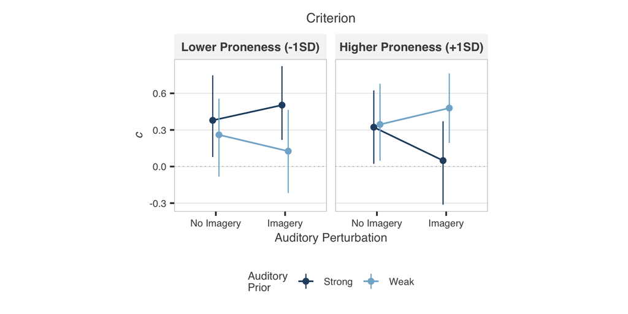

```r
p_crit_hl = ggplot(ef_crit_3way, aes(x = Perturbation, y = Criterion_c,
                                     colour = Prior, group = Prior)) +
  geom_hline(yintercept = 0, linetype = "dotted", colour = "grey65", linewidth = 0.3) +
  geom_line(linewidth = 0.7, position = prior_position) +
  geom_linerange(aes(ymin = Lower_HPD, ymax = Upper_HPD), linewidth = 0.5,
                 position = prior_position) +
  geom_point(size = 2, position = prior_position) +
  facet_wrap(~ Hallucination_Proneness, nrow = 1) +
  scale_colour_manual(values = c("Weak" = "#82B3D1", "Strong" = "#264E70"), limits = c("Strong", "Weak")) +
  theme_paper() +
  labs(title = "Criterion", x = "Auditory Perturbation",
       y = expression(italic(c)), color = "Auditory\nPrior")

print(p_crit_hl)
```

# 8. HGF Trait Parameters (Session-Level)

## 8.1 Model specification + load

```r
bmm.hgf.ppw = brm(zPPW ~ fam * musicvivid * lshs + (1 | SubjID),
                    data = d.hgf.session, family = gaussian(), prior = priors_hgf,
                    sample_prior = TRUE, seed = 666, chains = 4, cores = 4,
                    backend = "cmdstanr",
                    control = list(adapt_delta = 0.99))
saveRDS(bmm.hgf.ppw, "model_outputs/statistical_modelling_brms/experiment_1/hgf_prior_posterior_weight.rds")
```

```r
bmm.hgf.ppw = readRDS("model_outputs/statistical_modelling_brms/experiment_1/hgf_prior_posterior_weight.rds")

check_brms_diagnostics(bmm.hgf.ppw, "HGF prior-posterior weight")
```

```
## HGF prior-posterior weight passed diagnostics: max Rhat = 1.003; min bulk ESS = 1343; min tail ESS = 1935; divergences = 0
```

```r
report_bmm_fixef(bmm.hgf.ppw, caption = "HGF Trait: Prior-Posterior Weight (gaussian)")
```

HGF Trait: Prior-Posterior Weight (gaussian)

term

Estimate

Est.Error

2.5%

97.5%

BF10

H0

H1

Intercept

0.02

0.11

-0.18

0.23

NA

NA

NA

fam

-0.31

0.19

-0.70

0.07

0.62

musicvivid

0.06

0.20

-0.35

0.45

0.21

lshs

0.32

0.22

-0.10

0.76

0.65

fam:musicvivid

-0.16

0.38

-0.89

0.61

0.41

fam:lshs

0.09

0.39

-0.68

0.86

0.39

musicvivid:lshs

-0.02

0.38

-0.76

0.74

0.38

fam:musicvivid:lshs

0.85

0.66

-0.43

2.12

1.38

```r
write.csv(extract_bmm_fixef(bmm.hgf.ppw), "results/tables/exp1_fixef_hgf_ppw.csv", row.names = FALSE)
```

# 9. HGF State Parameters

## 9.1 Model specification + load

```r
# keep 3,000 post-warm-up draws per chain for state-model convergence
bmm.hgf.xprob = brm(zmu_xprob ~ fam * musicvivid * lshs + ztrialID + (1 + fam || SubjID),
                     data = d.hgf.trial, family = gaussian(), prior = priors_hgf,
                     sample_prior = TRUE, seed = 666, chains = 4, cores = 4,
                     iter = 4000, warmup = 1000,
                     backend = "cmdstanr")
saveRDS(bmm.hgf.xprob, "model_outputs/statistical_modelling_brms/experiment_1/hgf_signal_expectation.rds")
```

```r
bmm.hgf.xprob = readRDS("model_outputs/statistical_modelling_brms/experiment_1/hgf_signal_expectation.rds")

check_brms_diagnostics(bmm.hgf.xprob, "HGF pre-action signal expectation")
```

```
## HGF pre-action signal expectation passed diagnostics: max Rhat = 1.004; min bulk ESS = 1228; min tail ESS = 1772; divergences = 0
```

```r
report_bmm_fixef(bmm.hgf.xprob, caption = "HGF State: Signal Expectation (gaussian, + ztrialID)")
```

HGF State: Signal Expectation (gaussian, + ztrialID)

term

Estimate

Est.Error

2.5%

97.5%

BF10

H0

H1

Intercept

0.07

0.09

-0.12

0.25

NA

NA

NA

fam

0.38

0.14

0.11

0.67

4.60

musicvivid

0.27

0.05

0.17

0.38

2.41e+15

***

lshs

0.18

0.18

-0.20

0.53

0.32

ztrialID

-0.41

0.00

-0.42

-0.40

4.26e+14

***

fam:musicvivid

0.37

0.11

0.17

0.59

57.82

fam:lshs

0.79

0.28

0.24

1.33

14.72

musicvivid:lshs

0.12

0.12

-0.11

0.35

0.19

fam:musicvivid:lshs

3.19

0.24

2.72

3.65

8.69e+15

***

```r
write.csv(extract_bmm_fixef(bmm.hgf.xprob), "results/tables/exp1_fixef_hgf_xprob.csv", row.names = FALSE)
```

## 9.2 Signal Expectation

### Signal Expectation: Auditory Prior x Auditory Perturbation

```r
ef_xprob_fam_mv = emmeans(bmm.hgf.xprob, ~ fam * musicvivid,
                          at = list(musicvivid = c(-0.5, 0.5))) %>%
  as.data.frame() %>%
  mutate(
    fam = factor(ifelse(fam < 0, "Weak Prior", "Strong Prior"),
                 levels = c("Weak Prior", "Strong Prior")),
    musicvivid = factor(ifelse(musicvivid < 0, "No\nImagery", "Music\nImagery"),
                        levels = c("No\nImagery", "Music\nImagery"))
  )

ef_xprob_fam_mv %>%
  kbl(digits = 2, caption = "$\\hat{\\mu}_{xprob}$: Estimated Marginal Means by Auditory Prior x Auditory Perturbation") %>%
  kable_styling(bootstrap_options = c("striped", "hover", "condensed"), full_width = FALSE) %>%
  row_spec(0, bold = TRUE)
```

$\hat{\mu}_{xprob}$: Estimated Marginal Means by Auditory Prior x Auditory Perturbation

| fam | musicvivid | emmean | lower.HPD | upper.HPD |
| --- | --- | --- | --- | --- |
| Weak Prior | No Imagery | -0.17 | -0.41 | 0.08 |
| Strong Prior | No Imagery | 0.03 | -0.20 | 0.26 |
| Weak Prior | Music Imagery | -0.08 | -0.33 | 0.19 |
| Strong Prior | Music Imagery | 0.49 | 0.27 | 0.72 |

```r
write.csv(ef_xprob_fam_mv, "results/tables/exp1_emmeans_xprob_prior_x_perturbation.csv", row.names = FALSE)
```

```r
xprob_fam_mv_slopes = emtrends(bmm.hgf.xprob, ~ fam, var = "musicvivid",
                               at = list(fam = c(-0.5, 0.5))) %>%
  as.data.frame() %>%
  mutate(
    Prior = factor(ifelse(fam < 0, "Weak Prior", "Strong Prior"),
                   levels = c("Weak Prior", "Strong Prior"))
  ) %>%
  dplyr::select(Prior, musicvivid.trend, lower.HPD, upper.HPD)

xprob_fam_mv_slopes %>%
  kbl(digits = 3, col.names = c("Prior", "Slope", "Lower HPD", "Upper HPD"),
      caption = "$\\hat{\\mu}_{xprob}$: Auditory Perturbation Slopes at Each Auditory Prior Level") %>%
  kable_styling(bootstrap_options = c("striped", "hover", "condensed"), full_width = FALSE) %>%
  row_spec(0, bold = TRUE)
```

$\hat{\mu}_{xprob}$: Auditory Perturbation Slopes at Each Auditory Prior Level

| Prior | Slope | Lower HPD | Upper HPD |
| --- | --- | --- | --- |
| Weak Prior | 0.087 | -0.093 | 0.258 |
| Strong Prior | 0.460 | 0.349 | 0.569 |

```r
write.csv(xprob_fam_mv_slopes, "results/tables/exp1_slopes_xprob_perturbation_by_prior.csv", row.names = FALSE)
```

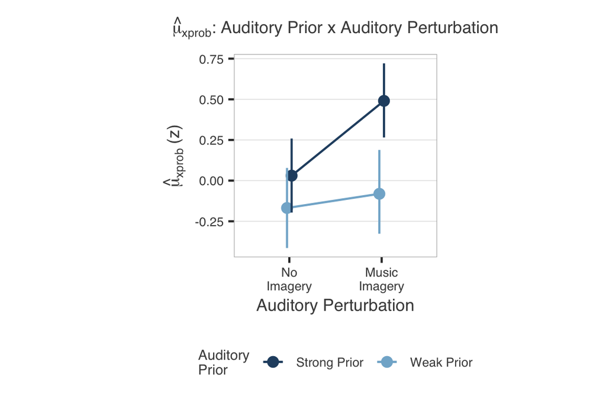

```r
fig_xprob_fam_mv = ggplot(ef_xprob_fam_mv,
                           aes(x = musicvivid, y = emmean, color = fam)) +
  geom_point(size = 3, position = position_dodge(0.1)) +
  geom_line(aes(group = fam), position = position_dodge(0.1)) +
  geom_errorbar(aes(ymin = lower.HPD, ymax = upper.HPD),
                width = 0, position = position_dodge(0.1)) +
  scale_colour_manual(values = c("Weak Prior" = "#82B3D1", "Strong Prior" = "#264E70"),
                      limits = c("Strong Prior", "Weak Prior")) +
  labs(title = expression(hat(mu)[xprob] * ": Auditory Prior x Auditory Perturbation"),
       x = "Auditory Perturbation", y = expression(hat(mu)[xprob] ~ "(z)"),
       color = "Auditory\nPrior") +
  theme_paper() +
  theme(axis.title = element_text(size = 12))

print(fig_xprob_fam_mv)
```

### Signal Expectation: Auditory Prior x Hallucination Proneness

```r
ef_xprob_prior_lshs = emmeans(bmm.hgf.xprob, ~ fam * lshs,
                              at = list(fam = c(-0.5, 0.5),
                                        lshs = c(-0.5, 0.5))) %>%
  as.data.frame() %>%
  mutate(
    fam = factor(ifelse(fam < 0, "Weak Prior", "Strong Prior"),
                 levels = c("Weak Prior", "Strong Prior")),
    lshs = factor(ifelse(lshs < 0, "Lower Proneness (-1SD)", "Higher Proneness (+1SD)"),
                  levels = c("Lower Proneness (-1SD)", "Higher Proneness (+1SD)"))
  )

ef_xprob_prior_lshs %>%
  kbl(digits = 2, caption = "$\\hat{\\mu}_{xprob}$: Estimated Marginal Means by Auditory Prior x Hallucination Proneness") %>%
  kable_styling(bootstrap_options = c("striped", "hover", "condensed"), full_width = FALSE) %>%
  row_spec(0, bold = TRUE)
```

$\hat{\mu}_{xprob}$: Estimated Marginal Means by Auditory Prior x Hallucination Proneness

| fam | lshs | emmean | lower.HPD | upper.HPD |
| --- | --- | --- | --- | --- |
| Weak Prior | Lower Proneness (-1SD) | -0.02 | -0.33 | 0.31 |
| Strong Prior | Lower Proneness (-1SD) | -0.03 | -0.34 | 0.30 |
| Weak Prior | Higher Proneness (+1SD) | -0.23 | -0.57 | 0.07 |
| Strong Prior | Higher Proneness (+1SD) | 0.55 | 0.23 | 0.86 |

```r
write.csv(ef_xprob_prior_lshs, "results/tables/exp1_emmeans_xprob_prior_x_hallucination_proneness.csv", row.names = FALSE)
```

```r
xprob_prior_lshs_slopes = emtrends(bmm.hgf.xprob, ~ fam, var = "lshs",
                                   at = list(fam = c(-0.5, 0.5))) %>%
  as.data.frame() %>%
  mutate(
    Prior = factor(ifelse(fam < 0, "Weak Prior", "Strong Prior"),
                   levels = c("Weak Prior", "Strong Prior"))
  ) %>%
  dplyr::select(Prior, lshs.trend, lower.HPD, upper.HPD)

xprob_prior_lshs_slopes %>%
  kbl(digits = 3, col.names = c("Prior", "Slope", "Lower HPD", "Upper HPD"),
      caption = "$\\hat{\\mu}_{xprob}$: Hallucination Proneness Slopes at Each Auditory Prior Level") %>%
  kable_styling(bootstrap_options = c("striped", "hover", "condensed"), full_width = FALSE) %>%
  row_spec(0, bold = TRUE)
```

$\hat{\mu}_{xprob}$: Hallucination Proneness Slopes at Each Auditory Prior Level

| Prior | Slope | Lower HPD | Upper HPD |
| --- | --- | --- | --- |
| Weak Prior | -0.215 | -0.652 | 0.236 |
| Strong Prior | 0.577 | 0.139 | 1.022 |

```r
write.csv(xprob_prior_lshs_slopes, "results/tables/exp1_slopes_xprob_hallucination_proneness_by_prior.csv", row.names = FALSE)
```

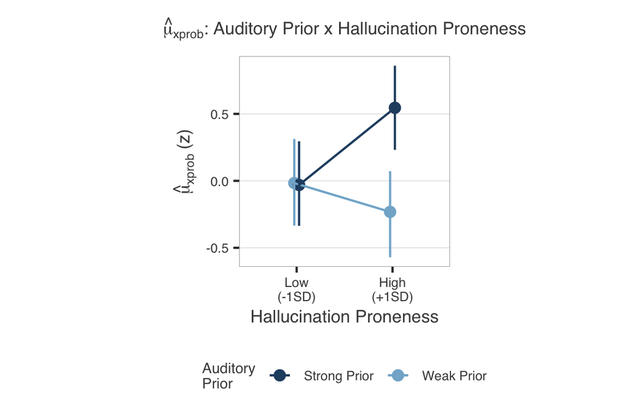

```r
fig_xprob_prior_lshs = ggplot(ef_xprob_prior_lshs,
                              aes(x = lshs, y = emmean, color = fam)) +
  geom_point(size = 3, position = position_dodge(0.1)) +
  geom_line(aes(group = fam), position = position_dodge(0.1)) +
  geom_errorbar(aes(ymin = lower.HPD, ymax = upper.HPD),
                width = 0, position = position_dodge(0.1)) +
  scale_colour_manual(values = c("Weak Prior" = "#82B3D1", "Strong Prior" = "#264E70"),
                      limits = c("Strong Prior", "Weak Prior")) +
  scale_x_discrete(labels = c("Low\n(-1SD)", "High\n(+1SD)")) +
  labs(title = expression(hat(mu)[xprob] * ": Auditory Prior x Hallucination Proneness"),
       x = "Hallucination Proneness", y = expression(hat(mu)[xprob] ~ "(z)"),
       color = "Auditory\nPrior") +
  theme_paper() +
  theme(axis.title = element_text(size = 12))

print(fig_xprob_prior_lshs)
```

### Signal Expectation: Auditory Prior x Auditory Perturbation x Hallucination Proneness

```r
ef_xprob_3way = emmeans(bmm.hgf.xprob, ~ fam * musicvivid * lshs,
                        at = list(musicvivid = c(-0.5, 0.5),
                                  lshs = c(-0.5, 0.5))) %>%
  as.data.frame() %>%
  mutate(
    fam = factor(ifelse(fam < 0, "Weak Prior", "Strong Prior"),
                 levels = c("Weak Prior", "Strong Prior")),
    musicvivid = factor(ifelse(musicvivid < 0, "No\nImagery", "Music\nImagery"),
                        levels = c("No\nImagery", "Music\nImagery")),
    lshs = factor(ifelse(lshs < 0, "Low (-1SD)", "High (+1SD)"),
                  levels = c("Low (-1SD)", "High (+1SD)"))
  ) %>%
  arrange(desc(lshs), musicvivid, fam) %>%
  mutate(Prior = factor(ifelse(fam == "Strong Prior", "Strong", "Weak"), levels = c("Strong", "Weak")),
         Perturbation = factor(ifelse(musicvivid == "Music\nImagery", "Imagery", "No Imagery"), levels = c("No Imagery", "Imagery")),
         Hallucination_Proneness = lshs) %>%
  dplyr::select(Prior, Perturbation, Hallucination_Proneness, Signal_Expectation = emmean, Lower_HPD = lower.HPD, Upper_HPD = upper.HPD)

ef_xprob_3way %>%
  kbl(digits = 2, caption = "$\\hat{\\mu}_{xprob}$: Estimated Marginal Means by Auditory Prior x Auditory Perturbation x Hallucination Proneness") %>%
  kable_styling(bootstrap_options = c("striped", "hover", "condensed"), full_width = FALSE) %>%
  row_spec(0, bold = TRUE)
```

$\hat{\mu}_{xprob}$: Estimated Marginal Means by Auditory Prior x Auditory Perturbation x Hallucination Proneness

| Prior | Perturbation | Hallucination_Proneness | Signal_Expectation | Lower_HPD | Upper_HPD |
| --- | --- | --- | --- | --- | --- |
| Weak | No Imagery | High (+1SD) | 0.09 | -0.23 | 0.44 |
| Strong | No Imagery | High (+1SD) | -0.11 | -0.43 | 0.22 |
| Weak | Imagery | High (+1SD) | -0.56 | -0.89 | -0.23 |
| Strong | Imagery | High (+1SD) | 1.20 | 0.87 | 1.55 |
| Weak | No Imagery | Low (-1SD) | -0.43 | -0.78 | -0.08 |
| Strong | No Imagery | Low (-1SD) | 0.17 | -0.14 | 0.53 |
| Weak | Imagery | Low (-1SD) | 0.40 | 0.03 | 0.76 |
| Strong | Imagery | Low (-1SD) | -0.23 | -0.55 | 0.10 |

```r
contrast_xprob_prior = contrast(emmeans(bmm.hgf.xprob, ~ fam | musicvivid * lshs, at = list(musicvivid = c(-0.5, 0.5), lshs = c(-0.5, 0.5))), method = list("Strong - Weak" = c(-1, 1))) %>%
  as.data.frame() %>%
  mutate(Perturbation = ifelse(musicvivid > 0, "Imagery", "No Imagery"), Hallucination_Proneness = ifelse(lshs > 0, "High (+1SD)", "Low (-1SD)")) %>%
  dplyr::select(Perturbation, Hallucination_Proneness, contrast, estimate, lower.HPD, upper.HPD)

write.csv(ef_xprob_3way, "results/tables/exp1_emmeans_xprob_prior_x_perturbation_x_hallucination_proneness.csv", row.names = FALSE)
write.csv(contrast_xprob_prior, "results/tables/exp1_contrasts_xprob_prior_by_perturbation_x_hallucination_proneness.csv", row.names = FALSE)
```

```r
xprob_3way_slopes = emtrends(bmm.hgf.xprob, ~ fam * lshs, var = "musicvivid",
                             at = list(fam = c(-0.5, 0.5),
                                       lshs = c(-0.5, 0.5))) %>%
  as.data.frame() %>%
  mutate(
    Prior = factor(ifelse(fam < 0, "Weak Prior", "Strong Prior"),
                   levels = c("Weak Prior", "Strong Prior")),
    Hallucination_Proneness = factor(ifelse(lshs < 0, "Lower Proneness (-1SD)", "Higher Proneness (+1SD)"),
                                     levels = c("Lower Proneness (-1SD)", "Higher Proneness (+1SD)"))
  ) %>%
  dplyr::select(Prior, Hallucination_Proneness, musicvivid.trend, lower.HPD, upper.HPD)

xprob_3way_slopes %>%
  kbl(digits = 3, col.names = c("Auditory Prior", "Hallucination Proneness", "Slope", "Lower HPD", "Upper HPD"),
      caption = "$\\hat{\\mu}_{xprob}$: Auditory Perturbation Slopes at Each Auditory Prior x Hallucination Proneness Cell") %>%
  kable_styling(bootstrap_options = c("striped", "hover", "condensed"), full_width = FALSE) %>%
  row_spec(0, bold = TRUE)
```

$\hat{\mu}_{xprob}$: Auditory Perturbation Slopes at Each Auditory Prior x Hallucination Proneness Cell

| Auditory Prior | Hallucination Proneness | Slope | Lower HPD | Upper HPD |
| --- | --- | --- | --- | --- |
| Weak Prior | Lower Proneness (-1SD) | 0.826 | 0.521 | 1.124 |
| Strong Prior | Lower Proneness (-1SD) | -0.399 | -0.608 | -0.187 |
| Weak Prior | Higher Proneness (+1SD) | -0.652 | -0.795 | -0.513 |
| Strong Prior | Higher Proneness (+1SD) | 1.317 | 1.119 | 1.508 |

```r
write.csv(xprob_3way_slopes, "results/tables/exp1_slopes_xprob_perturbation_by_prior_x_hallucination_proneness.csv", row.names = FALSE)
```

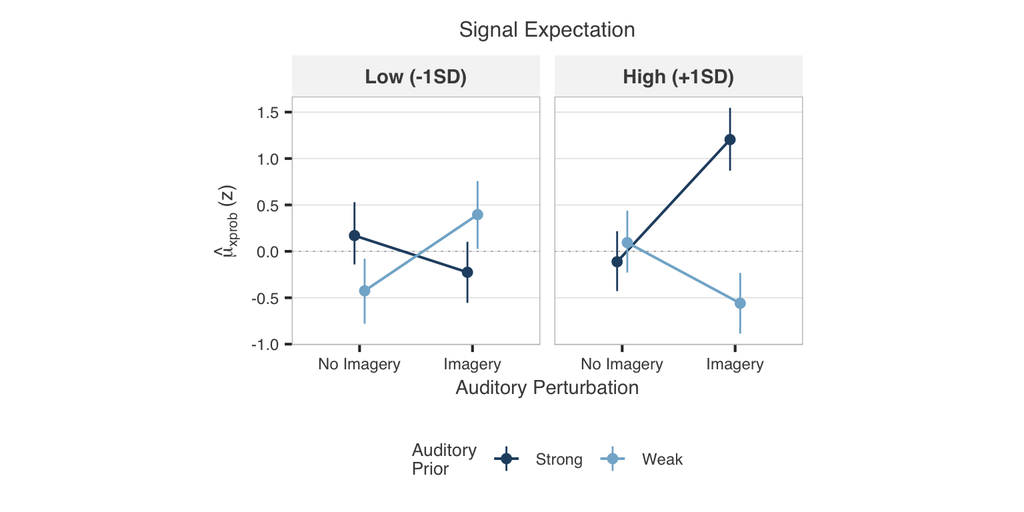

```r
p_xprob_hl = ggplot(ef_xprob_3way, aes(x = Perturbation, y = Signal_Expectation,
                                       colour = Prior, group = Prior)) +
  geom_hline(yintercept = 0, linetype = "dotted", colour = "grey65", linewidth = 0.3) +
  geom_line(linewidth = 0.7, position = prior_position) +
  geom_linerange(aes(ymin = Lower_HPD, ymax = Upper_HPD), linewidth = 0.5,
                 position = prior_position) +
  geom_point(size = 2, position = prior_position) +
  facet_wrap(~ Hallucination_Proneness, nrow = 1) +
  scale_colour_manual(values = c("Weak" = "#82B3D1", "Strong" = "#264E70"), limits = c("Strong", "Weak")) +
  theme_paper() +
  labs(title = "Signal Expectation", x = "Auditory Perturbation",
       y = expression(hat(mu)[xprob] * " (z)"), colour = "Auditory\nPrior")

print(p_xprob_hl)
```

# 10. Manuscript Figure

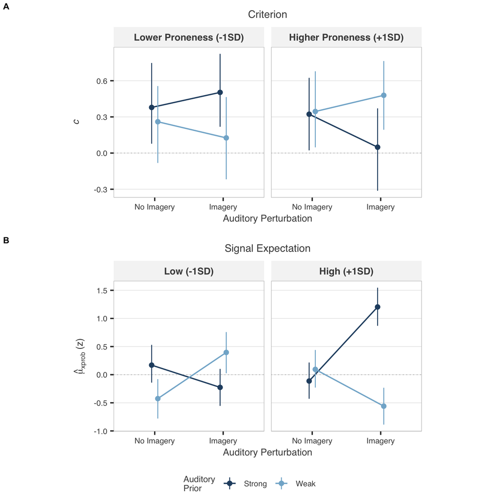

```r
fig3 = ggarrange(
  p_crit_hl, p_xprob_hl,
  nrow = 2, ncol = 1, labels = c("A", "B"),
  font.label = list(size = 10, face = "bold"), align = "hv",
  common.legend = TRUE, legend = "bottom"
)
fig3
```

```r
ggsave("results/figures/figure_3_exp1.png",
       plot = fig3, width = 16, height = 18, units = "cm", dpi = 300, bg = "white")
ggsave("results/figures/figure_3_exp1.pdf",
       plot = fig3, width = 16, height = 18, units = "cm", bg = "white")
```